# Assignment B: Computer Vision (CS7GV1)

## Van Allen Bruns Jr - 19329560

# 1) MNIST Classification (20 marks): You are provided with code mnist.py that trains a Convolutional Neural Network on MNIST dataset. You are required to modify this file.

#### mnist.py seen below, with learning_rate and weight_decay variables properly set into optimizer with all classification code rolled until a function defition called 'classify' and model selection added.

```
Test set: Average loss: 3.1965, Accuracy: 1004/10000 (10%)

Train Epoch: 1 [0/60000 (0%)]	Loss: 3.393386
Train Epoch: 1 [1280/60000 (2%)]	Loss: 3.107770
Train Epoch: 1 [2560/60000 (4%)]	Loss: 3.323505
Train Epoch: 1 [3840/60000 (6%)]	Loss: 3.369772
Train Epoch: 1 [5120/60000 (9%)]	Loss: 3.184495
Train Epoch: 1 [6400/60000 (11%)]	Loss: 3.245818
Train Epoch: 1 [7680/60000 (13%)]	Loss: 3.605466
Train Epoch: 1 [8960/60000 (15%)]	Loss: 2.963505
Train Epoch: 1 [10240/60000 (17%)]	Loss: 3.386882
Train Epoch: 1 [11520/60000 (19%)]	Loss: 3.107052
Train Epoch: 1 [12800/60000 (21%)]	Loss: 3.009974
Train Epoch: 1 [14080/60000 (23%)]	Loss: 3.199325
Train Epoch: 1 [15360/60000 (26%)]	Loss: 3.126656
Train Epoch: 1 [16640/60000 (28%)]	Loss: 3.238082
Train Epoch: 1 [17920/60000 (30%)]	Loss: 2.884939
Train Epoch: 1 [19200/60000 (32%)]	Loss: 2.801362
Train Epoch: 1 [20480/60000 (34%)]	Loss: 3.131588
Train Epoch: 1 [21760/60000 (36%)]	Loss: 2.962873
Train Epoch: 1 [23040/60000 (38%)]	Loss: 3.005158
Train Epoch: 1 [24320/60000 (41%)]	Loss: 3.100219
Train Epoch: 1 [25600/60000 (43%)]	Loss: 2.991755
Train Epoch: 1 [26880/60000 (45%)]	Loss: 3.249263
Train Epoch: 1 [28160/60000 (47%)]	Loss: 3.141305
Train Epoch: 1 [29440/60000 (49%)]	Loss: 2.980114
Train Epoch: 1 [30720/60000 (51%)]	Loss: 3.561982
Train Epoch: 1 [32000/60000 (53%)]	Loss: 3.049012
Train Epoch: 1 [33280/60000 (55%)]	Loss: 3.528145
Train Epoch: 1 [34560/60000 (58%)]	Loss: 3.107780
Train Epoch: 1 [35840/60000 (60%)]	Loss: 3.622491
Train Epoch: 1 [37120/60000 (62%)]	Loss: 3.435609
Train Epoch: 1 [38400/60000 (64%)]	Loss: 3.642093
Train Epoch: 1 [39680/60000 (66%)]	Loss: 3.357588
Train Epoch: 1 [40960/60000 (68%)]	Loss: 3.496396
Train Epoch: 1 [42240/60000 (70%)]	Loss: 3.060843
Train Epoch: 1 [43520/60000 (72%)]	Loss: 3.295287
Train Epoch: 1 [44800/60000 (75%)]	Loss: 3.168679
Train Epoch: 1 [46080/60000 (77%)]	Loss: 2.952425
Train Epoch: 1 [47360/60000 (79%)]	Loss: 3.287914
Train Epoch: 1 [48640/60000 (81%)]	Loss: 3.514517
Train Epoch: 1 [49920/60000 (83%)]	Loss: 3.392670
Train Epoch: 1 [51200/60000 (85%)]	Loss: 3.153057
Train Epoch: 1 [52480/60000 (87%)]	Loss: 3.234023
Train Epoch: 1 [53760/60000 (90%)]	Loss: 3.212214
Train Epoch: 1 [55040/60000 (92%)]	Loss: 2.727628
Train Epoch: 1 [56320/60000 (94%)]	Loss: 2.878388
Train Epoch: 1 [57600/60000 (96%)]	Loss: 3.179610
Train Epoch: 1 [58880/60000 (98%)]	Loss: 3.170258

Test set: Average loss: 3.1965, Accuracy: 1004/10000 (10%)
```

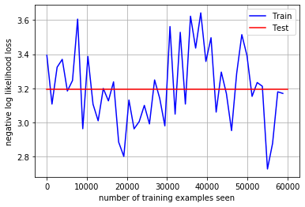

[figure not shown]

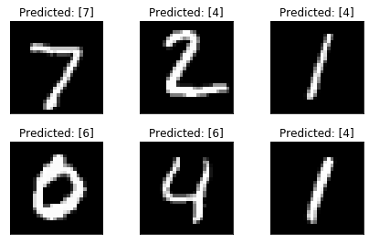

```python
from __future__ import print_function
import torch
import torch.nn as nn
import torch.nn.functional as F
import torch.optim as optim
from torchvision import datasets, transforms
import matplotlib.pyplot as plt
import numpy as np
import pandas as pd

# Training hyperparameters
epochs = 1
batch_size = 64
learning_rate = 0 # TODO
momentum = 0.9
weight_decay = 0 # TODO
log_interval = 20

class CNN(nn.Module):
    def __init__(self):
        super(CNN, self).__init__()
        self.conv1 = nn.Conv2d(in_channels=1, out_channels=16,
                               kernel_size=5, stride=1, padding=0)
        self.maxpool = nn.MaxPool2d(2)
        self.conv2 = nn.Conv2d(in_channels=16, out_channels=32,
                               kernel_size=3, stride=1, padding=0)
        self.fc1 = nn.Linear(in_features=800, out_features=128)
        self.fc2 = nn.Linear(in_features=128, out_features=10)

        nn.init.kaiming_normal_(self.conv1.weight, nonlinearity='relu')
        nn.init.kaiming_normal_(self.conv2.weight, nonlinearity='relu')
        nn.init.kaiming_normal_(self.fc1.weight, nonlinearity='relu')
        nn.init.kaiming_normal_(self.fc2.weight, nonlinearity='linear')

    def forward(self, x):
        x = self.conv1(x)
        x = F.relu(x)
        x = self.maxpool(x)
        x = self.conv2(x)
        x = F.relu(x)
        x = self.maxpool(x)
        x = x.view(-1, 800)
        x = self.fc1(x)
        x = F.relu(x)
        x = self.fc2(x)
        return F.log_softmax(x, dim=1)

class CNN2(nn.Module):
    def __init__(self):
        super(CNN2, self).__init__()
        self.conv1 = nn.Conv2d(in_channels=1, out_channels=32,
                               kernel_size=5, stride=1, padding=2)
        self.maxpool = nn.MaxPool2d(2)
        self.conv2 = nn.Conv2d(in_channels=24, out_channels=64,
                               kernel_size=3, stride=1, padding=2)
        self.fc1 = nn.Linear(in_features=1200, out_features=196)
        self.fc2 = nn.Linear(in_features=256, out_features=10)

        nn.init.kaiming_normal_(self.conv1.weight, nonlinearity='relu')
        nn.init.kaiming_normal_(self.conv2.weight, nonlinearity='relu')
        nn.init.kaiming_normal_(self.fc1.weight, nonlinearity='relu')
        nn.init.kaiming_normal_(self.fc2.weight, nonlinearity='linear')

    def forward(self, x):
        x = self.conv1(x)
        x = F.relu(x)
        x = self.maxpool(x)
        x = self.conv2(x)
        x = F.relu(x)
        x = self.maxpool(x)
        x = x.view(-1, 3136)
        x = self.fc1(x)
        x = F.relu(x)
        x = self.fc2(x)
        return F.log_softmax(x, dim=1)

class CNN3(nn.Module):
    def __init__(self):
        super(CNN3, self).__init__()
        # TODO

    def forward(self, x):
        # TODO
        return F.log_softmax(x, dim=1)

def plot_data(data, label, text):
    fig = plt.figure()
    for i in range(6):
        plt.subplot(2,3,i+1)
        plt.tight_layout()
        plt.imshow(data[i][0], cmap='gray', interpolation='none')
        plt.title(text + ": {}".format(label[i]))
        plt.xticks([])
        plt.yticks([])
    plt.show()

def predict_batch(model, device, test_loader):
    examples = enumerate(test_loader)
    model.eval()
    with torch.no_grad():
        batch_idx, (data, target) = next(examples)
        data, target = data.to(device), target.to(device)
        output = model(data)
        pred = output.cpu().data.max(1, keepdim=True)[1] # get the index of the max log-probability
        pred = pred.numpy()
    return data.cpu().data.numpy(), target.cpu().data.numpy(), pred

def plot_graph(train_x, train_y, test_x, test_y, ylabel=''):
    fig = plt.figure()
    plt.plot(train_x, train_y, color='blue')
    plt.plot(test_x, test_y, color='red')
    plt.legend(['Train', 'Test'], loc='upper right')
    plt.xlabel('number of training examples seen')
    plt.ylabel(ylabel)
    plt.grid()
    plt.show()

def train(model, device, train_loader, optimizer, epoch, losses=[], counter=[], errors=[]):
    model.train()
    correct=0
    for batch_idx, (data, target) in enumerate(train_loader):
        data, target = data.to(device), target.to(device)
        optimizer.zero_grad()
        output = model(data)
        loss = F.nll_loss(output, target)
        loss.backward()
        optimizer.step()
        if batch_idx % log_interval == 0:
            print('Train Epoch: {} [{}/{} ({:.0f}%)]\tLoss: {:.6f}'.format(
                epoch, batch_idx * len(data), len(train_loader.dataset),
                100. * batch_idx / len(train_loader), loss.item()))
            losses.append(loss.item())
            counter.append((batch_idx*batch_size) + ((epoch-1)*len(train_loader.dataset)))
        pred = output.max(1, keepdim=True)[1]
        correct += pred.eq(target.view_as(pred)).sum().item()
    errors.append(100. * (1 - correct / len(train_loader.dataset)))

def test(model, device, test_loader, losses=[], errors=[]):
    model.eval()
    test_loss = 0
    correct = 0
    with torch.no_grad():
        for data, target in test_loader:
            data, target = data.to(device), target.to(device)
            output = model(data)
            test_loss += F.nll_loss(output, target, reduction='sum').item() # sum up batch loss
            pred = output.max(1, keepdim=True)[1] # get the index of the max log-probability
            correct += pred.eq(target.view_as(pred)).sum().item()

    test_loss /= len(test_loader.dataset)
    print('\nTest set: Average loss: {:.4f}, Accuracy: {}/{} ({:.0f}%)\n'.format(
        test_loss, correct, len(test_loader.dataset),
        100. * correct / len(test_loader.dataset)))
    losses.append(test_loss)
    errors.append(100. *  (1 - correct / len(test_loader.dataset)))

def classify(train_data, test_data, cnn = 0):
    # data loaders
    train_loader = torch.utils.data.DataLoader(train_data, batch_size=batch_size, shuffle=True, **kwargs)
    test_loader = torch.utils.data.DataLoader(test_data, batch_size=batch_size, shuffle=False, **kwargs)

    # extract and plot random samples of data
    #examples = enumerate(test_loader)
    #batch_idx, (data, target) = next(examples)
    #plot_data(data, target, 'Ground truth')

    # model creation
    if (cnn == 0):
        model = CNN().to(device)
    elif (cnn == 1):
        model = CNN2().to(device)
    else:
        model = CNN3().to(device)

    # optimizer creation
    optimizer = optim.SGD(model.parameters(), lr=learning_rate, momentum=momentum, weight_decay=weight_decay)

    # lists for saving history
    train_losses = []
    train_counter = []
    test_losses = []
    test_counter = [i*len(train_loader.dataset) for i in range(epochs + 1)]
    train_errors = []
    test_errors = []
    error_counter = [i*len(train_loader.dataset) for i in range(epochs)]

    # test of randomly initialized model
    test(model, device, test_loader, losses=test_losses)

    # global training and testing loop
    for epoch in range(1, epochs + 1):
        train(model, device, train_loader, optimizer, epoch, losses=train_losses, counter=train_counter,
              errors=train_errors)
        test(model, device, test_loader, losses=test_losses, errors=test_errors)

    # plotting training history
    plot_graph(train_counter, train_losses, test_counter, test_losses, ylabel='negative log likelihood loss')
    plot_graph(error_counter, train_errors, error_counter, test_errors, ylabel='error (%)')

    # extract and plot random samples of data with predicted labels
    data, _, pred = predict_batch(model, device, test_loader)
    plot_data(data, pred, 'Predicted')

# data transformation
train_data = datasets.MNIST('./data', train=True, download=True,
               transform=transforms.Compose([
                   transforms.ToTensor(),
                   transforms.Normalize((0.1307,), (0.3081,))
               ]))
test_data = datasets.MNIST('./data', train=False,
               transform=transforms.Compose([
                   transforms.ToTensor(),
                   transforms.Normalize((0.1307,), (0.3081,))
               ]))

use_cuda = torch.cuda.is_available()
device = torch.device("cuda" if use_cuda else "cpu")
kwargs = {'num_workers': 1, 'pin_memory': True} if use_cuda else {}

classify(train_data, test_data)
```

## a) In the file mnist.py identify where the Stochastic Gradient Descent optimizer is created. Train the default CNN architecture by choosing appropriate parameter values for:

### i) Learning rate – explain what happens when you use too large or too small value and explain why it is happening.

This is a good learning rate.

```
Test set: Average loss: 3.4650, Accuracy: 1496/10000 (15%)

Train Epoch: 1 [0/60000 (0%)]	Loss: 3.698050
Train Epoch: 1 [1280/60000 (2%)]	Loss: 1.090706
Train Epoch: 1 [2560/60000 (4%)]	Loss: 0.424242
Train Epoch: 1 [3840/60000 (6%)]	Loss: 0.295106
Train Epoch: 1 [5120/60000 (9%)]	Loss: 0.198546
Train Epoch: 1 [6400/60000 (11%)]	Loss: 0.364278
Train Epoch: 1 [7680/60000 (13%)]	Loss: 0.454002
Train Epoch: 1 [8960/60000 (15%)]	Loss: 0.259035
Train Epoch: 1 [10240/60000 (17%)]	Loss: 0.104958
Train Epoch: 1 [11520/60000 (19%)]	Loss: 0.184284
Train Epoch: 1 [12800/60000 (21%)]	Loss: 0.112374
Train Epoch: 1 [14080/60000 (23%)]	Loss: 0.167404
Train Epoch: 1 [15360/60000 (26%)]	Loss: 0.331498
Train Epoch: 1 [16640/60000 (28%)]	Loss: 0.120936
Train Epoch: 1 [17920/60000 (30%)]	Loss: 0.070389
Train Epoch: 1 [19200/60000 (32%)]	Loss: 0.075462
Train Epoch: 1 [20480/60000 (34%)]	Loss: 0.117887
Train Epoch: 1 [21760/60000 (36%)]	Loss: 0.138202
Train Epoch: 1 [23040/60000 (38%)]	Loss: 0.114467
Train Epoch: 1 [24320/60000 (41%)]	Loss: 0.201018
Train Epoch: 1 [25600/60000 (43%)]	Loss: 0.111551
Train Epoch: 1 [26880/60000 (45%)]	Loss: 0.199463
Train Epoch: 1 [28160/60000 (47%)]	Loss: 0.044437
Train Epoch: 1 [29440/60000 (49%)]	Loss: 0.016283
Train Epoch: 1 [30720/60000 (51%)]	Loss: 0.212167
Train Epoch: 1 [32000/60000 (53%)]	Loss: 0.034338
Train Epoch: 1 [33280/60000 (55%)]	Loss: 0.054896
Train Epoch: 1 [34560/60000 (58%)]	Loss: 0.073656
Train Epoch: 1 [35840/60000 (60%)]	Loss: 0.022098
Train Epoch: 1 [37120/60000 (62%)]	Loss: 0.024491
Train Epoch: 1 [38400/60000 (64%)]	Loss: 0.079518
Train Epoch: 1 [39680/60000 (66%)]	Loss: 0.147543
Train Epoch: 1 [40960/60000 (68%)]	Loss: 0.019669
Train Epoch: 1 [42240/60000 (70%)]	Loss: 0.120444
Train Epoch: 1 [43520/60000 (72%)]	Loss: 0.030885
Train Epoch: 1 [44800/60000 (75%)]	Loss: 0.047267
Train Epoch: 1 [46080/60000 (77%)]	Loss: 0.094835
Train Epoch: 1 [47360/60000 (79%)]	Loss: 0.006863
Train Epoch: 1 [48640/60000 (81%)]	Loss: 0.084786
Train Epoch: 1 [49920/60000 (83%)]	Loss: 0.067677
Train Epoch: 1 [51200/60000 (85%)]	Loss: 0.177588
Train Epoch: 1 [52480/60000 (87%)]	Loss: 0.010246
Train Epoch: 1 [53760/60000 (90%)]	Loss: 0.041200
Train Epoch: 1 [55040/60000 (92%)]	Loss: 0.104251
Train Epoch: 1 [56320/60000 (94%)]	Loss: 0.010802
Train Epoch: 1 [57600/60000 (96%)]	Loss: 0.082660
Train Epoch: 1 [58880/60000 (98%)]	Loss: 0.062599

Test set: Average loss: 0.0608, Accuracy: 9802/10000 (98%)
```

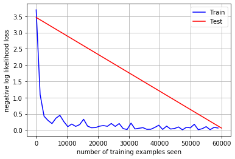

[figure not shown]

```python
learning_rate = 0.01
weight_decay = 0

classify(train_data, test_data)
```

When too small, the learning rate doesn't give enough time to fully train for predicting the numbers, and the accuracy suffers (as seen below). The predictions appear random, as if nothing has been learned.

```
Test set: Average loss: 6.1136, Accuracy: 797/10000 (8%)

Train Epoch: 1 [0/60000 (0%)]	Loss: 5.754940
Train Epoch: 1 [1280/60000 (2%)]	Loss: 4.982795
Train Epoch: 1 [2560/60000 (4%)]	Loss: 5.576721
Train Epoch: 1 [3840/60000 (6%)]	Loss: 6.273781
Train Epoch: 1 [5120/60000 (9%)]	Loss: 6.465814
Train Epoch: 1 [6400/60000 (11%)]	Loss: 5.620175
Train Epoch: 1 [7680/60000 (13%)]	Loss: 6.459218
Train Epoch: 1 [8960/60000 (15%)]	Loss: 6.394498
Train Epoch: 1 [10240/60000 (17%)]	Loss: 6.285637
Train Epoch: 1 [11520/60000 (19%)]	Loss: 5.236278
Train Epoch: 1 [12800/60000 (21%)]	Loss: 5.600549
Train Epoch: 1 [14080/60000 (23%)]	Loss: 5.580904
Train Epoch: 1 [15360/60000 (26%)]	Loss: 5.196988
Train Epoch: 1 [16640/60000 (28%)]	Loss: 5.315502
Train Epoch: 1 [17920/60000 (30%)]	Loss: 5.704613
Train Epoch: 1 [19200/60000 (32%)]	Loss: 5.355501
Train Epoch: 1 [20480/60000 (34%)]	Loss: 6.464248
Train Epoch: 1 [21760/60000 (36%)]	Loss: 6.207688
Train Epoch: 1 [23040/60000 (38%)]	Loss: 5.250154
Train Epoch: 1 [24320/60000 (41%)]	Loss: 5.811214
Train Epoch: 1 [25600/60000 (43%)]	Loss: 5.593506
Train Epoch: 1 [26880/60000 (45%)]	Loss: 5.966580
Train Epoch: 1 [28160/60000 (47%)]	Loss: 5.311558
Train Epoch: 1 [29440/60000 (49%)]	Loss: 5.762704
Train Epoch: 1 [30720/60000 (51%)]	Loss: 6.016133
Train Epoch: 1 [32000/60000 (53%)]	Loss: 5.383783
Train Epoch: 1 [33280/60000 (55%)]	Loss: 4.836391
Train Epoch: 1 [34560/60000 (58%)]	Loss: 5.531671
Train Epoch: 1 [35840/60000 (60%)]	Loss: 5.464693
Train Epoch: 1 [37120/60000 (62%)]	Loss: 5.609002
Train Epoch: 1 [38400/60000 (64%)]	Loss: 5.496767
Train Epoch: 1 [39680/60000 (66%)]	Loss: 4.956368
Train Epoch: 1 [40960/60000 (68%)]	Loss: 5.506952
Train Epoch: 1 [42240/60000 (70%)]	Loss: 6.446501
Train Epoch: 1 [43520/60000 (72%)]	Loss: 4.775454
Train Epoch: 1 [44800/60000 (75%)]	Loss: 5.061293
Train Epoch: 1 [46080/60000 (77%)]	Loss: 6.030942
Train Epoch: 1 [47360/60000 (79%)]	Loss: 5.727315
Train Epoch: 1 [48640/60000 (81%)]	Loss: 5.164025
Train Epoch: 1 [49920/60000 (83%)]	Loss: 5.253055
Train Epoch: 1 [51200/60000 (85%)]	Loss: 5.303717
Train Epoch: 1 [52480/60000 (87%)]	Loss: 6.031817
Train Epoch: 1 [53760/60000 (90%)]	Loss: 5.032175
Train Epoch: 1 [55040/60000 (92%)]	Loss: 5.667021
Train Epoch: 1 [56320/60000 (94%)]	Loss: 4.884751
Train Epoch: 1 [57600/60000 (96%)]	Loss: 5.414357
Train Epoch: 1 [58880/60000 (98%)]	Loss: 4.699121

Test set: Average loss: 5.2663, Accuracy: 762/10000 (8%)
```

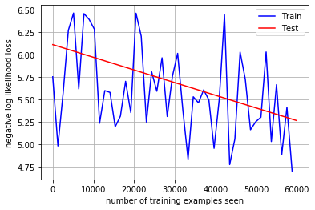

[figure not shown]

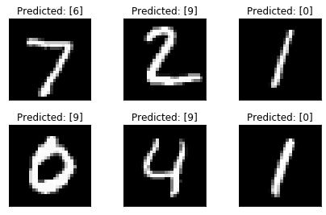

```python
learning_rate = 0.0000001
weight_decay = 0

classify(train_data, test_data)
```

```
Test set: Average loss: 3.6297, Accuracy: 1270/10000 (13%)

Train Epoch: 1 [0/60000 (0%)]	Loss: 3.505681
Train Epoch: 1 [1280/60000 (2%)]	Loss: 2.292782
Train Epoch: 1 [2560/60000 (4%)]	Loss: 2.318620
Train Epoch: 1 [3840/60000 (6%)]	Loss: 2.290956
Train Epoch: 1 [5120/60000 (9%)]	Loss: 2.352277
Train Epoch: 1 [6400/60000 (11%)]	Loss: 2.317029
Train Epoch: 1 [7680/60000 (13%)]	Loss: 2.294469
Train Epoch: 1 [8960/60000 (15%)]	Loss: 2.337482
Train Epoch: 1 [10240/60000 (17%)]	Loss: 2.307503
Train Epoch: 1 [11520/60000 (19%)]	Loss: 2.328830
Train Epoch: 1 [12800/60000 (21%)]	Loss: 2.301449
Train Epoch: 1 [14080/60000 (23%)]	Loss: 2.345647
Train Epoch: 1 [15360/60000 (26%)]	Loss: 2.298637
Train Epoch: 1 [16640/60000 (28%)]	Loss: 2.319195
Train Epoch: 1 [17920/60000 (30%)]	Loss: 2.311959
Train Epoch: 1 [19200/60000 (32%)]	Loss: 2.348181
Train Epoch: 1 [20480/60000 (34%)]	Loss: 2.312810
Train Epoch: 1 [21760/60000 (36%)]	Loss: 2.295138
Train Epoch: 1 [23040/60000 (38%)]	Loss: 2.304301
Train Epoch: 1 [24320/60000 (41%)]	Loss: 2.322741
Train Epoch: 1 [25600/60000 (43%)]	Loss: 2.279443
Train Epoch: 1 [26880/60000 (45%)]	Loss: 2.310814
Train Epoch: 1 [28160/60000 (47%)]	Loss: 2.317381
Train Epoch: 1 [29440/60000 (49%)]	Loss: 2.322912
Train Epoch: 1 [30720/60000 (51%)]	Loss: 2.343309
Train Epoch: 1 [32000/60000 (53%)]	Loss: 2.317431
Train Epoch: 1 [33280/60000 (55%)]	Loss: 2.321656
Train Epoch: 1 [34560/60000 (58%)]	Loss: 2.275015
Train Epoch: 1 [35840/60000 (60%)]	Loss: 2.301281
Train Epoch: 1 [37120/60000 (62%)]	Loss: 2.327952
Train Epoch: 1 [38400/60000 (64%)]	Loss: 2.335282
Train Epoch: 1 [39680/60000 (66%)]	Loss: 2.295087
Train Epoch: 1 [40960/60000 (68%)]	Loss: 2.320386
Train Epoch: 1 [42240/60000 (70%)]	Loss: 2.294997
Train Epoch: 1 [43520/60000 (72%)]	Loss: 2.319325
Train Epoch: 1 [44800/60000 (75%)]	Loss: 2.317997
Train Epoch: 1 [46080/60000 (77%)]	Loss: 2.314893
Train Epoch: 1 [47360/60000 (79%)]	Loss: 2.323201
Train Epoch: 1 [48640/60000 (81%)]	Loss: 2.321008
Train Epoch: 1 [49920/60000 (83%)]	Loss: 2.306774
Train Epoch: 1 [51200/60000 (85%)]	Loss: 2.363826
Train Epoch: 1 [52480/60000 (87%)]	Loss: 2.340192
Train Epoch: 1 [53760/60000 (90%)]	Loss: 2.305913
Train Epoch: 1 [55040/60000 (92%)]	Loss: 2.331717
Train Epoch: 1 [56320/60000 (94%)]	Loss: 2.292557
Train Epoch: 1 [57600/60000 (96%)]	Loss: 2.325677
Train Epoch: 1 [58880/60000 (98%)]	Loss: 2.292785

Test set: Average loss: 2.3132, Accuracy: 1010/10000 (10%)
```

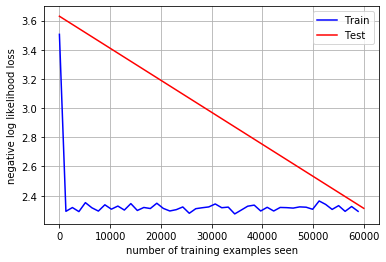

[figure not shown]

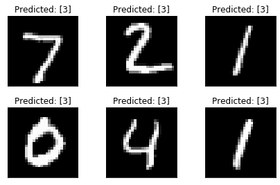

```python
learning_rate = 0.25
weight_decay = 0

classify(train_data, test_data)
```

### ii) Weight decay – explain what happens when you use too large or too small regularization and explain why it is happening.

This seems to be the max for weight decay without lowering accuracy. It's just enough to help add consistency to the predictions (better handling noise).

```
Test set: Average loss: 4.5649, Accuracy: 924/10000 (9%)

Train Epoch: 1 [0/60000 (0%)]	Loss: 4.537688
Train Epoch: 1 [1280/60000 (2%)]	Loss: 1.332008
Train Epoch: 1 [2560/60000 (4%)]	Loss: 0.778131
Train Epoch: 1 [3840/60000 (6%)]	Loss: 0.395832
Train Epoch: 1 [5120/60000 (9%)]	Loss: 0.300101
Train Epoch: 1 [6400/60000 (11%)]	Loss: 0.379285
Train Epoch: 1 [7680/60000 (13%)]	Loss: 0.104374
Train Epoch: 1 [8960/60000 (15%)]	Loss: 0.161219
Train Epoch: 1 [10240/60000 (17%)]	Loss: 0.226293
Train Epoch: 1 [11520/60000 (19%)]	Loss: 0.078571
Train Epoch: 1 [12800/60000 (21%)]	Loss: 0.117213
Train Epoch: 1 [14080/60000 (23%)]	Loss: 0.242341
Train Epoch: 1 [15360/60000 (26%)]	Loss: 0.173943
Train Epoch: 1 [16640/60000 (28%)]	Loss: 0.240795
Train Epoch: 1 [17920/60000 (30%)]	Loss: 0.081958
Train Epoch: 1 [19200/60000 (32%)]	Loss: 0.073142
Train Epoch: 1 [20480/60000 (34%)]	Loss: 0.086511
Train Epoch: 1 [21760/60000 (36%)]	Loss: 0.148120
Train Epoch: 1 [23040/60000 (38%)]	Loss: 0.137526
Train Epoch: 1 [24320/60000 (41%)]	Loss: 0.028787
Train Epoch: 1 [25600/60000 (43%)]	Loss: 0.127834
Train Epoch: 1 [26880/60000 (45%)]	Loss: 0.036714
Train Epoch: 1 [28160/60000 (47%)]	Loss: 0.014483
Train Epoch: 1 [29440/60000 (49%)]	Loss: 0.033107
Train Epoch: 1 [30720/60000 (51%)]	Loss: 0.051553
Train Epoch: 1 [32000/60000 (53%)]	Loss: 0.083353
Train Epoch: 1 [33280/60000 (55%)]	Loss: 0.205428
Train Epoch: 1 [34560/60000 (58%)]	Loss: 0.022018
Train Epoch: 1 [35840/60000 (60%)]	Loss: 0.113356
Train Epoch: 1 [37120/60000 (62%)]	Loss: 0.023574
Train Epoch: 1 [38400/60000 (64%)]	Loss: 0.106489
Train Epoch: 1 [39680/60000 (66%)]	Loss: 0.098275
Train Epoch: 1 [40960/60000 (68%)]	Loss: 0.091059
Train Epoch: 1 [42240/60000 (70%)]	Loss: 0.087230
Train Epoch: 1 [43520/60000 (72%)]	Loss: 0.048506
Train Epoch: 1 [44800/60000 (75%)]	Loss: 0.131750
Train Epoch: 1 [46080/60000 (77%)]	Loss: 0.032240
Train Epoch: 1 [47360/60000 (79%)]	Loss: 0.075242
Train Epoch: 1 [48640/60000 (81%)]	Loss: 0.072233
Train Epoch: 1 [49920/60000 (83%)]	Loss: 0.130410
Train Epoch: 1 [51200/60000 (85%)]	Loss: 0.052948
Train Epoch: 1 [52480/60000 (87%)]	Loss: 0.005259
Train Epoch: 1 [53760/60000 (90%)]	Loss: 0.068390
Train Epoch: 1 [55040/60000 (92%)]	Loss: 0.043664
Train Epoch: 1 [56320/60000 (94%)]	Loss: 0.015748
Train Epoch: 1 [57600/60000 (96%)]	Loss: 0.030198
Train Epoch: 1 [58880/60000 (98%)]	Loss: 0.082100

Test set: Average loss: 0.0548, Accuracy: 9818/10000 (98%)
```

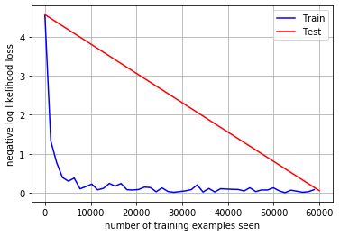

[figure not shown]

```python
learning_rate = 0.01
weight_decay = 0.001

classify(train_data, test_data)
```

Going too small for weight decay didn't seem to affect the accuracy, as it just becomes not a factor.

```
Test set: Average loss: 4.7497, Accuracy: 675/10000 (7%)

Train Epoch: 1 [0/60000 (0%)]	Loss: 4.718410
Train Epoch: 1 [1280/60000 (2%)]	Loss: 0.770563
Train Epoch: 1 [2560/60000 (4%)]	Loss: 0.596622
Train Epoch: 1 [3840/60000 (6%)]	Loss: 0.300822
Train Epoch: 1 [5120/60000 (9%)]	Loss: 0.170456
Train Epoch: 1 [6400/60000 (11%)]	Loss: 0.121560
Train Epoch: 1 [7680/60000 (13%)]	Loss: 0.126537
Train Epoch: 1 [8960/60000 (15%)]	Loss: 0.214386
Train Epoch: 1 [10240/60000 (17%)]	Loss: 0.225779
Train Epoch: 1 [11520/60000 (19%)]	Loss: 0.047149
Train Epoch: 1 [12800/60000 (21%)]	Loss: 0.074792
Train Epoch: 1 [14080/60000 (23%)]	Loss: 0.220824
Train Epoch: 1 [15360/60000 (26%)]	Loss: 0.060799
Train Epoch: 1 [16640/60000 (28%)]	Loss: 0.140960
Train Epoch: 1 [17920/60000 (30%)]	Loss: 0.185527
Train Epoch: 1 [19200/60000 (32%)]	Loss: 0.100535
Train Epoch: 1 [20480/60000 (34%)]	Loss: 0.145591
Train Epoch: 1 [21760/60000 (36%)]	Loss: 0.062575
Train Epoch: 1 [23040/60000 (38%)]	Loss: 0.055748
Train Epoch: 1 [24320/60000 (41%)]	Loss: 0.067474
Train Epoch: 1 [25600/60000 (43%)]	Loss: 0.162936
Train Epoch: 1 [26880/60000 (45%)]	Loss: 0.172653
Train Epoch: 1 [28160/60000 (47%)]	Loss: 0.161247
Train Epoch: 1 [29440/60000 (49%)]	Loss: 0.152994
Train Epoch: 1 [30720/60000 (51%)]	Loss: 0.097116
Train Epoch: 1 [32000/60000 (53%)]	Loss: 0.095515
Train Epoch: 1 [33280/60000 (55%)]	Loss: 0.074065
Train Epoch: 1 [34560/60000 (58%)]	Loss: 0.095338
Train Epoch: 1 [35840/60000 (60%)]	Loss: 0.078173
Train Epoch: 1 [37120/60000 (62%)]	Loss: 0.108594
Train Epoch: 1 [38400/60000 (64%)]	Loss: 0.053066
Train Epoch: 1 [39680/60000 (66%)]	Loss: 0.067907
Train Epoch: 1 [40960/60000 (68%)]	Loss: 0.090355
Train Epoch: 1 [42240/60000 (70%)]	Loss: 0.048498
Train Epoch: 1 [43520/60000 (72%)]	Loss: 0.046612
Train Epoch: 1 [44800/60000 (75%)]	Loss: 0.136966
Train Epoch: 1 [46080/60000 (77%)]	Loss: 0.048620
Train Epoch: 1 [47360/60000 (79%)]	Loss: 0.018699
Train Epoch: 1 [48640/60000 (81%)]	Loss: 0.020801
Train Epoch: 1 [49920/60000 (83%)]	Loss: 0.038501
Train Epoch: 1 [51200/60000 (85%)]	Loss: 0.047340
Train Epoch: 1 [52480/60000 (87%)]	Loss: 0.018510
Train Epoch: 1 [53760/60000 (90%)]	Loss: 0.138554
Train Epoch: 1 [55040/60000 (92%)]	Loss: 0.028832
Train Epoch: 1 [56320/60000 (94%)]	Loss: 0.065844
Train Epoch: 1 [57600/60000 (96%)]	Loss: 0.188099
Train Epoch: 1 [58880/60000 (98%)]	Loss: 0.061419

Test set: Average loss: 0.0549, Accuracy: 9829/10000 (98%)
```

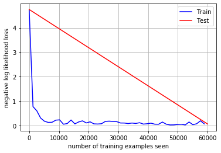

[figure not shown]

```python
learning_rate = 0.01
weight_decay = 0.0000000001

classify(train_data, test_data)
```

When too large, it's as if the weight decay is suffocating the learning, acting as if the learning rate is lower.

```
Test set: Average loss: 4.5469, Accuracy: 1086/10000 (11%)

Train Epoch: 1 [0/60000 (0%)]	Loss: 4.682109
Train Epoch: 1 [1280/60000 (2%)]	Loss: 0.832269
Train Epoch: 1 [2560/60000 (4%)]	Loss: 0.631336
Train Epoch: 1 [3840/60000 (6%)]	Loss: 0.658880
Train Epoch: 1 [5120/60000 (9%)]	Loss: 0.788937
Train Epoch: 1 [6400/60000 (11%)]	Loss: 0.775510
Train Epoch: 1 [7680/60000 (13%)]	Loss: 0.543527
Train Epoch: 1 [8960/60000 (15%)]	Loss: 0.661001
Train Epoch: 1 [10240/60000 (17%)]	Loss: 0.838874
Train Epoch: 1 [11520/60000 (19%)]	Loss: 0.633967
Train Epoch: 1 [12800/60000 (21%)]	Loss: 0.537567
Train Epoch: 1 [14080/60000 (23%)]	Loss: 0.482828
Train Epoch: 1 [15360/60000 (26%)]	Loss: 0.564153
Train Epoch: 1 [16640/60000 (28%)]	Loss: 0.549060
Train Epoch: 1 [17920/60000 (30%)]	Loss: 0.588347
Train Epoch: 1 [19200/60000 (32%)]	Loss: 0.574233
Train Epoch: 1 [20480/60000 (34%)]	Loss: 0.648889
Train Epoch: 1 [21760/60000 (36%)]	Loss: 0.657011
Train Epoch: 1 [23040/60000 (38%)]	Loss: 0.579816
Train Epoch: 1 [24320/60000 (41%)]	Loss: 0.550685
Train Epoch: 1 [25600/60000 (43%)]	Loss: 0.548235
Train Epoch: 1 [26880/60000 (45%)]	Loss: 0.719808
Train Epoch: 1 [28160/60000 (47%)]	Loss: 0.586897
Train Epoch: 1 [29440/60000 (49%)]	Loss: 0.540528
Train Epoch: 1 [30720/60000 (51%)]	Loss: 0.522788
Train Epoch: 1 [32000/60000 (53%)]	Loss: 0.498423
Train Epoch: 1 [33280/60000 (55%)]	Loss: 0.512038
Train Epoch: 1 [34560/60000 (58%)]	Loss: 0.567846
Train Epoch: 1 [35840/60000 (60%)]	Loss: 0.552930
Train Epoch: 1 [37120/60000 (62%)]	Loss: 0.509691
Train Epoch: 1 [38400/60000 (64%)]	Loss: 0.727555
Train Epoch: 1 [39680/60000 (66%)]	Loss: 0.598678
Train Epoch: 1 [40960/60000 (68%)]	Loss: 0.679269
Train Epoch: 1 [42240/60000 (70%)]	Loss: 0.585621
Train Epoch: 1 [43520/60000 (72%)]	Loss: 0.480149
Train Epoch: 1 [44800/60000 (75%)]	Loss: 0.562858
Train Epoch: 1 [46080/60000 (77%)]	Loss: 0.600921
Train Epoch: 1 [47360/60000 (79%)]	Loss: 0.471749
Train Epoch: 1 [48640/60000 (81%)]	Loss: 0.841721
Train Epoch: 1 [49920/60000 (83%)]	Loss: 0.512594
Train Epoch: 1 [51200/60000 (85%)]	Loss: 0.588077
Train Epoch: 1 [52480/60000 (87%)]	Loss: 0.668559
Train Epoch: 1 [53760/60000 (90%)]	Loss: 0.534148
Train Epoch: 1 [55040/60000 (92%)]	Loss: 0.402949
Train Epoch: 1 [56320/60000 (94%)]	Loss: 0.675394
Train Epoch: 1 [57600/60000 (96%)]	Loss: 0.512572
Train Epoch: 1 [58880/60000 (98%)]	Loss: 0.540897

Test set: Average loss: 0.4983, Accuracy: 9073/10000 (91%)
```

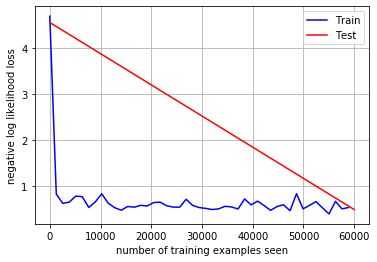

[figure not shown]

```python
learning_rate = 0.01
weight_decay = 0.25

classify(train_data, test_data)
```

## b) Correct the mistakes in CNN2 and train it on MNIST train set. Desired architecture of CNN2 is displayed on following diagam:

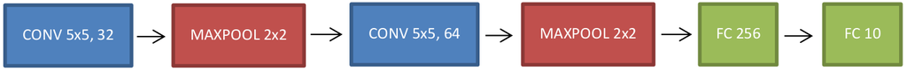

## CONV KxK, N represents N features extracted by KxK filters, FC N represent fully-connected layer with N nodes. Set the padding so each convolution preserves input feature size.

```
Test set: Average loss: 4.1367, Accuracy: 556/10000 (6%)

Train Epoch: 1 [0/60000 (0%)]	Loss: 4.213980
Train Epoch: 1 [1280/60000 (2%)]	Loss: 0.685389
Train Epoch: 1 [2560/60000 (4%)]	Loss: 0.443323
Train Epoch: 1 [3840/60000 (6%)]	Loss: 0.255289
Train Epoch: 1 [5120/60000 (9%)]	Loss: 0.442326
Train Epoch: 1 [6400/60000 (11%)]	Loss: 0.267475
Train Epoch: 1 [7680/60000 (13%)]	Loss: 0.070052
Train Epoch: 1 [8960/60000 (15%)]	Loss: 0.089268
Train Epoch: 1 [10240/60000 (17%)]	Loss: 0.021983
Train Epoch: 1 [11520/60000 (19%)]	Loss: 0.225064
Train Epoch: 1 [12800/60000 (21%)]	Loss: 0.107088
Train Epoch: 1 [14080/60000 (23%)]	Loss: 0.072019
Train Epoch: 1 [15360/60000 (26%)]	Loss: 0.075603
Train Epoch: 1 [16640/60000 (28%)]	Loss: 0.140056
Train Epoch: 1 [17920/60000 (30%)]	Loss: 0.079575
Train Epoch: 1 [19200/60000 (32%)]	Loss: 0.022258
Train Epoch: 1 [20480/60000 (34%)]	Loss: 0.060288
Train Epoch: 1 [21760/60000 (36%)]	Loss: 0.137833
Train Epoch: 1 [23040/60000 (38%)]	Loss: 0.087651
Train Epoch: 1 [24320/60000 (41%)]	Loss: 0.072862
Train Epoch: 1 [25600/60000 (43%)]	Loss: 0.035181
Train Epoch: 1 [26880/60000 (45%)]	Loss: 0.128743
Train Epoch: 1 [28160/60000 (47%)]	Loss: 0.111983
Train Epoch: 1 [29440/60000 (49%)]	Loss: 0.117472
Train Epoch: 1 [30720/60000 (51%)]	Loss: 0.024418
Train Epoch: 1 [32000/60000 (53%)]	Loss: 0.023451
Train Epoch: 1 [33280/60000 (55%)]	Loss: 0.148935
Train Epoch: 1 [34560/60000 (58%)]	Loss: 0.064929
Train Epoch: 1 [35840/60000 (60%)]	Loss: 0.023645
Train Epoch: 1 [37120/60000 (62%)]	Loss: 0.042538
Train Epoch: 1 [38400/60000 (64%)]	Loss: 0.025085
Train Epoch: 1 [39680/60000 (66%)]	Loss: 0.021006
Train Epoch: 1 [40960/60000 (68%)]	Loss: 0.141939
Train Epoch: 1 [42240/60000 (70%)]	Loss: 0.085275
Train Epoch: 1 [43520/60000 (72%)]	Loss: 0.155908
Train Epoch: 1 [44800/60000 (75%)]	Loss: 0.035348
Train Epoch: 1 [46080/60000 (77%)]	Loss: 0.099350
Train Epoch: 1 [47360/60000 (79%)]	Loss: 0.036298
Train Epoch: 1 [48640/60000 (81%)]	Loss: 0.049069
Train Epoch: 1 [49920/60000 (83%)]	Loss: 0.149619
Train Epoch: 1 [51200/60000 (85%)]	Loss: 0.039096
Train Epoch: 1 [52480/60000 (87%)]	Loss: 0.031988
Train Epoch: 1 [53760/60000 (90%)]	Loss: 0.088630
Train Epoch: 1 [55040/60000 (92%)]	Loss: 0.074380
Train Epoch: 1 [56320/60000 (94%)]	Loss: 0.071608
Train Epoch: 1 [57600/60000 (96%)]	Loss: 0.028856
Train Epoch: 1 [58880/60000 (98%)]	Loss: 0.122490

Test set: Average loss: 0.0483, Accuracy: 9846/10000 (98%)
```

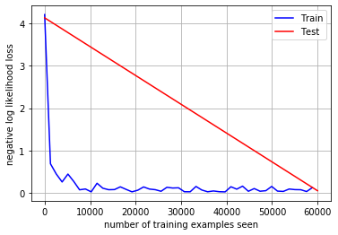

[figure not shown]

```python
class CNN2(nn.Module):
    def __init__(self):
        super(CNN2, self).__init__()
        # ---  1 x 28 x 28 ---
        self.conv1 = nn.Conv2d(in_channels=1, out_channels=32,
                               kernel_size=5, stride=1, padding=2)
        # --- 32 x 28 x 28 ---
        self.maxpool = nn.MaxPool2d(2)
        # --- 32 x 14 x 14 ---
        self.conv2 = nn.Conv2d(in_channels=32, out_channels=64,
                               kernel_size=5, stride=1, padding=2)
        # --- 64 x 14 x 14 ---
        #self.maxpool = nn.MaxPool2d(2)
        # --- 64 x  7 x  7 ---
        self.fc1 = nn.Linear(in_features=3136, out_features=256)
        self.fc2 = nn.Linear(in_features=256, out_features=10)

        nn.init.kaiming_normal_(self.conv1.weight, nonlinearity='relu')
        nn.init.kaiming_normal_(self.conv2.weight, nonlinearity='relu')
        nn.init.kaiming_normal_(self.fc1.weight, nonlinearity='relu')
        nn.init.kaiming_normal_(self.fc2.weight, nonlinearity='linear')

    def forward(self, x):
        x = self.conv1(x)
        x = F.relu(x)
        x = self.maxpool(x)
        x = self.conv2(x)
        x = F.relu(x)
        x = self.maxpool(x)
        x = x.view(-1, 3136)
        x = self.fc1(x)
        x = F.relu(x)
        x = self.fc2(x)

        return F.log_softmax(x, dim=1)

learning_rate = 0.01
weight_decay = 0.001

classify(train_data, test_data, 1)
```

## c) Change dataset to fashion MNIST (https://research.zalando.com/welcome/mission/research-projects/fashion-mnist/, hint: take a look at torchvision.datasets), estimate the dataset mean and standard deviation and use it to normalize the data in the data loader.

```
Test set: Average loss: 4.3270, Accuracy: 643/10000 (6%)

Train Epoch: 1 [0/60000 (0%)]	Loss: 4.660766
Train Epoch: 1 [1280/60000 (2%)]	Loss: 0.736601
Train Epoch: 1 [2560/60000 (4%)]	Loss: 0.795502
Train Epoch: 1 [3840/60000 (6%)]	Loss: 0.530865
Train Epoch: 1 [5120/60000 (9%)]	Loss: 0.361153
Train Epoch: 1 [6400/60000 (11%)]	Loss: 0.434735
Train Epoch: 1 [7680/60000 (13%)]	Loss: 0.443674
Train Epoch: 1 [8960/60000 (15%)]	Loss: 0.437778
Train Epoch: 1 [10240/60000 (17%)]	Loss: 0.455582
Train Epoch: 1 [11520/60000 (19%)]	Loss: 0.433907
Train Epoch: 1 [12800/60000 (21%)]	Loss: 0.318959
Train Epoch: 1 [14080/60000 (23%)]	Loss: 0.412167
Train Epoch: 1 [15360/60000 (26%)]	Loss: 0.608008
Train Epoch: 1 [16640/60000 (28%)]	Loss: 0.377788
Train Epoch: 1 [17920/60000 (30%)]	Loss: 0.523446
Train Epoch: 1 [19200/60000 (32%)]	Loss: 0.432296
Train Epoch: 1 [20480/60000 (34%)]	Loss: 0.537166
Train Epoch: 1 [21760/60000 (36%)]	Loss: 0.338162
Train Epoch: 1 [23040/60000 (38%)]	Loss: 0.359733
Train Epoch: 1 [24320/60000 (41%)]	Loss: 0.485033
Train Epoch: 1 [25600/60000 (43%)]	Loss: 0.337759
Train Epoch: 1 [26880/60000 (45%)]	Loss: 0.335838
Train Epoch: 1 [28160/60000 (47%)]	Loss: 0.389701
Train Epoch: 1 [29440/60000 (49%)]	Loss: 0.390276
Train Epoch: 1 [30720/60000 (51%)]	Loss: 0.335500
Train Epoch: 1 [32000/60000 (53%)]	Loss: 0.336370
Train Epoch: 1 [33280/60000 (55%)]	Loss: 0.405090
Train Epoch: 1 [34560/60000 (58%)]	Loss: 0.329423
Train Epoch: 1 [35840/60000 (60%)]	Loss: 0.170317
Train Epoch: 1 [37120/60000 (62%)]	Loss: 0.255613
Train Epoch: 1 [38400/60000 (64%)]	Loss: 0.264178
Train Epoch: 1 [39680/60000 (66%)]	Loss: 0.493520
Train Epoch: 1 [40960/60000 (68%)]	Loss: 0.462434
Train Epoch: 1 [42240/60000 (70%)]	Loss: 0.249846
Train Epoch: 1 [43520/60000 (72%)]	Loss: 0.502968
Train Epoch: 1 [44800/60000 (75%)]	Loss: 0.466937
Train Epoch: 1 [46080/60000 (77%)]	Loss: 0.360077
Train Epoch: 1 [47360/60000 (79%)]	Loss: 0.337072
Train Epoch: 1 [48640/60000 (81%)]	Loss: 0.409756
Train Epoch: 1 [49920/60000 (83%)]	Loss: 0.232822
Train Epoch: 1 [51200/60000 (85%)]	Loss: 0.285453
Train Epoch: 1 [52480/60000 (87%)]	Loss: 0.430669
Train Epoch: 1 [53760/60000 (90%)]	Loss: 0.209795
Train Epoch: 1 [55040/60000 (92%)]	Loss: 0.241030
Train Epoch: 1 [56320/60000 (94%)]	Loss: 0.479793
Train Epoch: 1 [57600/60000 (96%)]	Loss: 0.262256
Train Epoch: 1 [58880/60000 (98%)]	Loss: 0.310284

Test set: Average loss: 0.3314, Accuracy: 8817/10000 (88%)
```

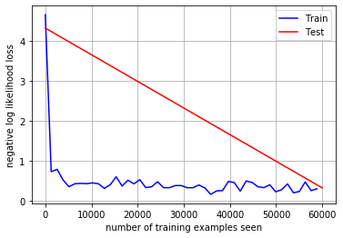

[figure not shown]

[figure not shown]

```python
# data transformation
train_data_f = datasets.FashionMNIST('./data', train=True, download=True,
               transform=transforms.Compose([
                   transforms.ToTensor()
               ]))

# data loaders
train_loader = torch.utils.data.DataLoader(train_data_f, batch_size=batch_size, shuffle=True, **kwargs)

# get mean and standard deviation from the training data
loader_enum = enumerate(train_loader)
_, (train_loader_data, _) = next(loader_enum)
mean = train_loader_data.mean()
std = train_loader_data.std()

# data transformation
train_data_f = datasets.FashionMNIST('./data', train=True, download=True,
               transform=transforms.Compose([
                   transforms.ToTensor(),
                   transforms.Normalize((mean,), (std,))
               ]))
test_data_f = datasets.FashionMNIST('./data', train=False,
               transform=transforms.Compose([
                   transforms.ToTensor(),
                   transforms.Normalize((mean,), (std,))
               ]))

classify(train_data_f, test_data_f, 1)
```

## d) Design CNN3 with additional regularization of your choosing. Explain benefits of such regularization and report its accurracy on fashion MNIST and its relative improvement over CNN2.

Adde two additional convolutions. It seems to give a slight increase to the prediction accuracy, but it can also add complexity without much benefit.

```
Test set: Average loss: 3.1707, Accuracy: 1194/10000 (12%)

Train Epoch: 1 [0/60000 (0%)]	Loss: 2.934339
Train Epoch: 1 [1280/60000 (2%)]	Loss: 1.566372
Train Epoch: 1 [2560/60000 (4%)]	Loss: 1.068106
Train Epoch: 1 [3840/60000 (6%)]	Loss: 0.727890
Train Epoch: 1 [5120/60000 (9%)]	Loss: 0.805432
Train Epoch: 1 [6400/60000 (11%)]	Loss: 0.697885
Train Epoch: 1 [7680/60000 (13%)]	Loss: 0.355364
Train Epoch: 1 [8960/60000 (15%)]	Loss: 0.555734
Train Epoch: 1 [10240/60000 (17%)]	Loss: 0.484847
Train Epoch: 1 [11520/60000 (19%)]	Loss: 0.542700
Train Epoch: 1 [12800/60000 (21%)]	Loss: 0.275922
Train Epoch: 1 [14080/60000 (23%)]	Loss: 0.252581
Train Epoch: 1 [15360/60000 (26%)]	Loss: 0.354795
Train Epoch: 1 [16640/60000 (28%)]	Loss: 0.355727
Train Epoch: 1 [17920/60000 (30%)]	Loss: 0.617883
Train Epoch: 1 [19200/60000 (32%)]	Loss: 0.383023
Train Epoch: 1 [20480/60000 (34%)]	Loss: 0.391581
Train Epoch: 1 [21760/60000 (36%)]	Loss: 0.253918
Train Epoch: 1 [23040/60000 (38%)]	Loss: 0.519077
Train Epoch: 1 [24320/60000 (41%)]	Loss: 0.240885
Train Epoch: 1 [25600/60000 (43%)]	Loss: 0.305659
Train Epoch: 1 [26880/60000 (45%)]	Loss: 0.529151
Train Epoch: 1 [28160/60000 (47%)]	Loss: 0.382026
Train Epoch: 1 [29440/60000 (49%)]	Loss: 0.634668
Train Epoch: 1 [30720/60000 (51%)]	Loss: 0.345839
Train Epoch: 1 [32000/60000 (53%)]	Loss: 0.372606
Train Epoch: 1 [33280/60000 (55%)]	Loss: 0.354874
Train Epoch: 1 [34560/60000 (58%)]	Loss: 0.429940
Train Epoch: 1 [35840/60000 (60%)]	Loss: 0.353222
Train Epoch: 1 [37120/60000 (62%)]	Loss: 0.469130
Train Epoch: 1 [38400/60000 (64%)]	Loss: 0.259785
Train Epoch: 1 [39680/60000 (66%)]	Loss: 0.224079
Train Epoch: 1 [40960/60000 (68%)]	Loss: 0.406880
Train Epoch: 1 [42240/60000 (70%)]	Loss: 0.407608
Train Epoch: 1 [43520/60000 (72%)]	Loss: 0.331620
Train Epoch: 1 [44800/60000 (75%)]	Loss: 0.186731
Train Epoch: 1 [46080/60000 (77%)]	Loss: 0.344637
Train Epoch: 1 [47360/60000 (79%)]	Loss: 0.280292
Train Epoch: 1 [48640/60000 (81%)]	Loss: 0.301814
Train Epoch: 1 [49920/60000 (83%)]	Loss: 0.294475
Train Epoch: 1 [51200/60000 (85%)]	Loss: 0.388174
Train Epoch: 1 [52480/60000 (87%)]	Loss: 0.309052
Train Epoch: 1 [53760/60000 (90%)]	Loss: 0.293647
Train Epoch: 1 [55040/60000 (92%)]	Loss: 0.250666
Train Epoch: 1 [56320/60000 (94%)]	Loss: 0.200811
Train Epoch: 1 [57600/60000 (96%)]	Loss: 0.451598
Train Epoch: 1 [58880/60000 (98%)]	Loss: 0.345104

Test set: Average loss: 0.3140, Accuracy: 8863/10000 (89%)
```

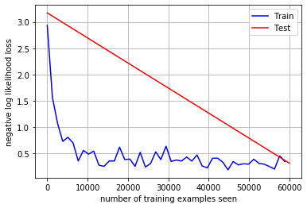

[figure not shown]

[figure not shown]

```python
class CNN3(nn.Module):
    def __init__(self):
        super(CNN3, self).__init__()
        # ---   1 x 28 x 28 ---
        self.conv1 = nn.Conv2d(in_channels=1, out_channels=32,
                               kernel_size=3, stride=1, padding=1)
        self.conv2 = nn.Conv2d(in_channels=32, out_channels=64,
                               kernel_size=3, stride=1, padding=1)
        # ---  64 x 28 x 28 ---
        self.maxpool = nn.MaxPool2d(2)
        # ---  64 x 14 x 14 ---
        self.conv3 = nn.Conv2d(in_channels=64, out_channels=128,
                               kernel_size=3, stride=1, padding=1)
        # --- 128 x 14 x 14 ---
        self.conv4 = nn.Conv2d(in_channels=128, out_channels=256,
                               kernel_size=3, stride=1, padding=1)
        # --- 256 x 14 x 14 ---
        #self.maxpool = nn.MaxPool2d(2)
        # --- 256 x  7 x  7 ---
        self.fc1 = nn.Linear(in_features=12544, out_features=512)
        self.fc2 = nn.Linear(in_features=512, out_features=10)

        nn.init.kaiming_normal_(self.conv1.weight, nonlinearity='relu')
        nn.init.kaiming_normal_(self.conv2.weight, nonlinearity='relu')
        nn.init.kaiming_normal_(self.conv3.weight, nonlinearity='relu')
        nn.init.kaiming_normal_(self.conv4.weight, nonlinearity='relu')
        nn.init.kaiming_normal_(self.fc1.weight, nonlinearity='relu')
        nn.init.kaiming_normal_(self.fc2.weight, nonlinearity='linear')

    def forward(self, x):
        x = self.conv1(x)
        x = F.relu(x)
        x = self.conv2(x)
        x = F.relu(x)
        x = self.maxpool(x)
        x = self.conv3(x)
        x = F.relu(x)
        x = self.conv4(x)
        x = F.relu(x)
        x = self.maxpool(x)
        x = x.view(-1, 12544)
        x = self.fc1(x)
        x = F.relu(x)
        x = self.fc2(x)

        return F.log_softmax(x, dim=1)

classify(train_data_f, test_data_f, 2)
```

## e) Download file YourEmail_in.csv from the course drive. File contains 5x5 array of integers X. Manually compute valid convolution

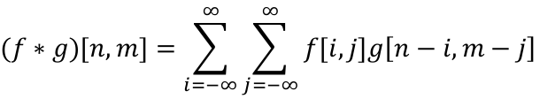

## of w and X and submit output in file named YourEmail_out.csv (note the difference between convolution and cross-correlation, see https://en.wikipedia.org/wiki/Convolution).

```python
def convolute(a, b):
    # select which input to use as the filter
    use_a = a.size < b.size

    # set output rows and columns based on input sizes, and flip the filter
    if (use_a):
        num_rows = len(b) - len(a) + 1
        num_columns = len(b[0]) - len(a[0]) + 1
        a = np.fliplr(np.flipud(a))
    else:
        num_rows = len(a) - len(b) + 1
        num_columns = len(a[0]) - len(b[0]) + 1
        b = np.fliplr(np.flipud(b))

    out = np.zeros((num_rows, num_columns))

    # iterate through each cell for the output
    for i in range(num_rows):
        for j in range(num_columns):
            if (use_a):
                out[i,j] = np.sum(a * b[i:num_rows + i, j:num_columns + j])
            else:
                out[i,j] = np.sum(b * a[i:num_rows + i, j:num_columns + j])

    return out


X = np.array(pd.read_csv('./BRUNSJRV@TCD.IE_in.csv', header=None))
w = np.array([[1, 0, 1], [0, 0, 0], [-1, 0 ,-1]])

out = convolute(w, X)

print(out)
pd.DataFrame(out).to_csv('./submission/BRUNSJRV@TCD.IE_out.csv', header=False, index=False)
```

```
[[   8.  119.   95.]
 [ -15.  -44.  367.]
 [  -2.  -60. -163.]]
```

## f) Download file YourEmail_network.csv from the course drive. File contains network definiton in the following format:

## i) Convolution, N, K – convolution layer with N feature maps and KxK filters

## ii) Maxpool, K – max pooling layer KxK pooling window

## iii) Fully-connected, N – fully connected layer with N neurons

## All convolutions use same padding that preserves input feature size. All convolutional and fully-connected layers use bias. The network is used on 32x32 RGB images (3 input channels). Calculate the number of parameters and the number of FLOPS of this network and submit them in YourEmail_params.csv each of the 2 values in separate row (number of parameters in the first row).

```python
# out_size = XxY (eg 32x32 pixels)
def describeNetwork(net_def, n, out_size):
    params = 0
    flops = 0
    net_def_size = len(net_def)

    for i in range(net_def_size):
        if (net_def[i, 0] == 'convolution'):
            m = net_def[i, 1]
            k = net_def[i, 2]

            # from slides:    N×M×K×K + M
            params = params + n * m * k * k + m

            # from slides:    N×M×K×K×X×Y
            flops = flops + n * m * k * k * out_size

            # output is next input
            n = m
        elif (net_def[i, 0] == 'maxpool'):
            k = net_def[i, 1]

            # maxpool reduces each dimension by k
            out_size = out_size / k / k
        elif (net_def[i, 0] == 'fully-connected'):
            # for first fc, flatten input
            n = n * out_size
            m = net_def[i, 1]

            # from slides:    N×M + M
            params = params + n * m + m

            # from slides:    N×M
            flops = flops + n * m

            # output is next input
            n = m

            # next input is already flattened
            out_size = 1
        else:
            raise Exception('Unknown type in network definition: {}'.format(net_def[i, 0]))

        #print(params, flops, in_chan, out_size)

    return [[params], [flops]]

net_def = np.array(pd.read_csv('./BRUNSJRV@TCD.IE_network.csv', header=None))

# 3 channels for rgb, 32x32 pixels
net_des = describeNetwork(net_def, 3, 32*32)

print(net_def)
print(net_des)

pd.DataFrame(net_des).to_csv('./submission/BRUNSJRV@TCD.IE_params.csv', header=False, index=False)
```

```
[['convolution' 24 7.0]
 ['convolution' 50 5.0]
 ['maxpool' 2 nan]
 ['convolution' 100 3.0]
 ['maxpool' 4 nan]
 ['fully-connected' 256 nan]
 ['fully-connected' 10 nan]]
[[491128.0], [46264832.0]]
```